# Self Organizing Maps and Text Mining - Visualizing Shakespeare (Part 1)

Daniel Tanner

25 June, 2017

A couple months ago I published some examples of using the R package `kohonen` and player stats from the 2015/2016 NBA season to make Self Organizing Maps ([check it out here](https://clarkdatalabs.github.io/soms/SOM_NBA)). That post covered the basics of Self Organizing Maps and the the basic plot types supported by `kohonen`.

Since that post, I’ve been playing with around with text mining and a corpus of the dramas of Shakespeare. The central questions these next two posts explore is:

*Can we use SOMs to see relationships between plays (part 1) or characters ([part 2](https://clarkdatalabs.github.io/soms/SOM_Shakespeare_Part_2)) based only on an analysis of their spoken vocabulary?*

This tutorial is designed so that no files need to be downloaded seperately from this document. Run code blocks sequentially to follow along.

# VERSION WARNING

This tutorial was written using the `kohonen` package version 2.0.19. Some of the code will not work in the most recent version of this package. To install 2.0.19, run the following:

```r
packageurl <- "https://cran.r-project.org/src/contrib/Archive/kohonen/kohonen_2.0.19.tar.gz"
install.packages(packageurl, repos = NULL, type = "source")
```

I hope to update all of the SOM tutorials to run properly on `kohonen` v3 in the near future.

# Shakespeare’s Dramas

The following script downloads a zipped folder containing all of the text of 37 of Shakespeare’s plays (originally [available at lexically.net](http://lexically.net/wordsmith/support/shakespeare.html)). It sets up a table (`play_table`) which contains all of the information we will be working with, including the complete text of each play.

```r
td <- tempdir()
tf <- tempfile(tmpdir = td)

download.file("https://github.com/clarkdatalabs/soms/raw/master/ShakespearePlaysPlus.zip",
    tf)

fname <- unzip(tf, list = TRUE)$Name[1]
unzip(tf, exdir = td, overwrite = TRUE)
fpath <- file.path(td, fname)
remove(fname)
unlink(tf)
```

Within the `ShakespearePlaysPlus` folder there are subfolders categorizing works by genre. We’ll use this as metadata for plots later, so we want to capture it in our table.

```r
genres <- list.dirs(fpath, full.names = FALSE, recursive = FALSE)
```

We build a dataframe with a row for each play and columns for play title, genre, and text:

```r
library("readr")
play_table <- data.frame(play = character(), genre = character(), text = character())

for (genre in genres) {
    plays <- list.files(file.path(fpath, genre), pattern = ".txt")
    for (play in plays) {
        play.text <- read_file(file.path(fpath, genre, play), locale(encoding = "UTF-16"))
        play.name <- gsub(".txt", "", play)
        play_table <- rbind(play_table, data.frame(play = play.name, genre = genre,
            text = play.text))
    }
}
remove(genre, plays, play, play.name, play.text)
```

Finally, we clean up everything from the temporary download except the table we’ve created:

```r
unlink(td, recursive = FALSE)
```

# Working with `tm`

## Forming & Cleaning a Corpus

We will be using the `tm` package for text mining. The fundemental object we’ll be working with is a *corpus*, within which we have one *document* per play.

```r
library("tm")

play.vec <- VectorSource(play_table[, "text"])
play.corpus <- Corpus(play.vec)
```

We can see the start of the contents of the first document in our corpus:

```r
substr(play.corpus[[1]]$content, 1, 400)
```

```
## [1] "< Shakespeare -- A MIDSUMMER-NIGHT'S DREAM >\n\n\n< from Online Library of Liberty (http://oll.libertyfund.org) >\n\n\n< Unicode .txt version by Mike Scott (http://www.lexically.net) >\n\n\n< from \"The Complete Works of William Shakespeare\" >\n\n\n< ed. with a glossary by W.J. Craig M.A. >…
```

Without using `substr` we would see the entire text of *A Midsummer-Night’s Dream* - over 110,000 characters instead of just the first 400. Yikes!

You can see there are lots of stage instructions and other metadata tags that are all enclosed in angle brackets. To transform the contents of documents within our corpus, we need to define a function that does exactly what we want: strip out anything within angle brackets.

```r
striptags <- function(x) gsub(x, pattern = "<[^>]*>", replacement = "")
```

The `tm_map` function applies functions to our corpus. Many of the functions we’ll use are already defined on corpus objects. Our `striptags` function, however, is not. It will need to be put within the `content_transformer` wrapper function so it applies to the contents of each document within our corpus.

```r
play.corpus <- tm_map(play.corpus, content_transformer(striptags))
```

```r
substr(play.corpus[[1]]$content, 1, 400)
```

```
## [1] "\n\n\n\n\n\n\n\n\n\n\n\n\n\n\n\n\n\n\n\n\n\n\n\n\n\n\n\n\n\n\n\n\n\n\n\n\n\n\n\n\n\n\n\n\n\n\n\n\n\n\n\n\n\n\n\n\n\t\n\n\n\tNow, fair Hippolyta, our nuptial hour\n\n\n\tDraws on apace: four happy days bring in\n\n\n\tAnother moon; but O! methinks how slow\n\n\n\tThis old moon wanes; she ling…
```

Next we want to really clean up our texts. The `tm` package has functions for stripping punctuation, numbers, whitespace, and the most common words (we don’t want to be comparing counts of “and” and “to”). We can change everything to lower case using `tolower()` from base R, but again we’ll need to wrap this in `content_transformer` so `tm_map` knows to apply this to the contents of each document. We’ll also use a function from the `SnowballC` package to cut words down to common stems for comparison.

*Note: this may take a few minutes to run.*

```r
library("SnowballC")

play.corpus <- tm_map(play.corpus, removePunctuation)
play.corpus <- tm_map(play.corpus, removeNumbers)
play.corpus <- tm_map(play.corpus, content_transformer(tolower))
play.corpus <- tm_map(play.corpus, removeWords, stopwords("english"))
play.corpus <- tm_map(play.corpus, stemDocument)
play.corpus <- tm_map(play.corpus, stripWhitespace)
play.corpus <- tm_map(play.corpus, removePunctuation)
```

```r
substr(play.corpus[[1]]$content, 1, 400)
```

```
## [1] " now fair hippolyta nuptial hour draw apac four happi day bring anoth moon o methink slow old moon wane linger desires like step dame dowager long wither young man revenue four day will quick steep night four night will quick dream away time moon like silver bow newbent heaven shall behold n…
```

The functions that rely on english dictionaries had a bit of trouble with the Shakespearean English, but they’re close enough for our analysis.

## Document Term Matrix

Next we’ll create what’s called a Document Term Matrix. In this matrix, there will be row for each document and a column for each word (in our case, word *stem*) appearing in our corpus. Entries in the matrix are simple counts of the number of times a word appeared in the corresponding document.

```r
play.DTM <- DocumentTermMatrix(play.corpus)
```

## Restrict to Shared Words

This matrix currently has columns for 25313 different words or word stems. Many of these, including character names, only appear in a single play. We want to restrict our comparison to terms that are somewhat common across the collection of 37 plays. Restricting the [sparsity](https://en.wikipedia.org/wiki/Sparse_matrix) of our Document Term Matrix has this effect.

```r
play.DTM.modified <- removeSparseTerms(play.DTM, 0.8)
```

```r
ncol(play.DTM.modified)
```

```
## [1] 4100
```

This has greatly reduced the number of terms that we will be using to compare plays.

## Normalize Play Vectors

Next, I’ve decided I only care about the distribution of words within a play, not the length of the play. I’ll scale each row to be a length 1 vector. This way the length of the play will not impact the SOM.

```r
play.DTM.modified <- t(apply(play.DTM.modified, 1, function(x) x/sqrt(sum(x^2))))
```

# Making a SOM

We’re going to be training our SOM using the rows of our document term matrix as vectors for plays. These are 4100 dimensional, length one vectors, with scaled counts of word stems for each play.

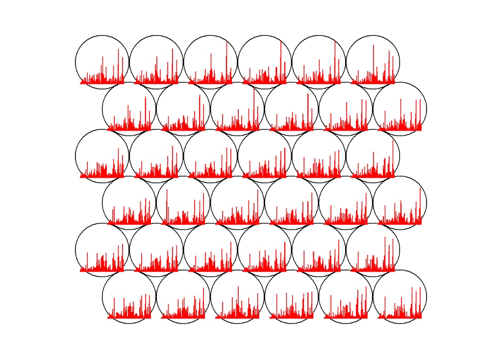

```r
library(kohonen)

play.SOM <- som(play.DTM.modified, grid = somgrid(6, 6, "hexagonal"), toroidal = FALSE)
plot(play.SOM)
```

The default plot for this SOM tries to visualize the representative vectors for each cell in our SOM. It’s a pretty meaningless picture of where these vectors lie in 4100-space. Instead, we will plot the *play* vectors back onto our map. We stored the genre classification in `play_table` which we can use to distinguish between the three genres (“comedies”, “historical”, and “tragedies”) using color.

```r
palette.3 <- c("firebrick1", "darkolivegreen3", "dodgerblue2")
```

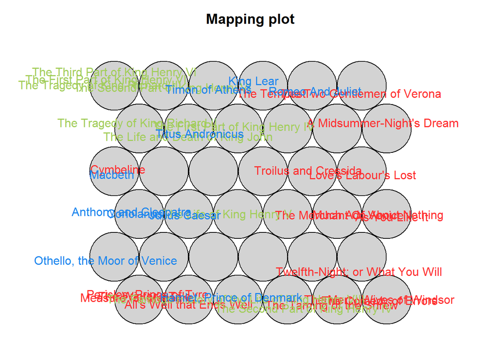

```r
plot(play.SOM,
     type = "mapping",
     col = palette.3[as.factor(play_table$genre)],
     bgcol = "lightgray",
     labels = play_table$play)
```

There appears to be a relationship between genre and language (red = “comedies”, green = “historical”, blue = “tragedies”). However, this is not a particularly clean visualization. There are two main problems that we will address below.

- There are too many labeled points, which become illegible.
- The gray backgrounds of the cells don’t communicate anything. It would be nice if they could be used to convey distance of a cell to it’s neighbors, like in the `dist.neighbours` type SOMs.

## Labeling Selected Plays

First, we’ll just make a list of the plays we want labeled, and represent the rest with *x*.

```r
plays.to.plot <- c("Romeo And Juliet",
                   "Julius Caesar",
                   "King Lear",
                   "Macbeth",
                   "Othello, the Moor of Venice",
                   "The Tragedy of King Richard II",
                   "The Tragedy of King Richard III",
                   "The Tempest",
                   "The Taming of the Shrew")
play.labels <- c()
X <- as.vector(play_table$play)
for (i in 1:nrow(play_table)){
  if (X[i] %in% plays.to.plot){play.labels[i] <- X[i]}
  else{play.labels[i]<-"x"}
}
```

## Visualizing Cell Distance

Next, we want to essentially combine two types of kohonen SOM functions, `mapping` and `dist.neighbours`. To do this we will write our own function to calculate the distance of a cell’s representative vector to all others, strongly weighing the neighboring cells. We’ll then use this to set the background color using the `mapping` type SOM. Don’t worry about the details.

```r
code.distances <- function(SOM) {
    N <- nrow(SOM$codes)
    # calculate all pairwise distances
    pairwise.distances = c()
    for (i in 1:N) {
        list <- matrix()
        for (j in 1:N) {
            list[j] <- dist(rbind(SOM$codes[i, ], SOM$codes[j, ]))
        }
        pairwise.distances <- cbind(pairwise.distances, list)
    }

    ## distance coefficient function, to be applied to geometric GRID distances
    d.coef <- function(x) {
        if (x == 0) {
            return(0)
        } else {
            return(1/(x^4))
        }
    }
    distance.coefficients <- apply(kohonen::unit.distances(SOM$grid, SOM$toroidal),
        c(1, 2), d.coef)

    # calculate scaled sum of distances
    A <- distance.coefficients * pairwise.distances
    scaled.dist.sums <- (colSums(A) - min(colSums(A)))/(max(colSums(A)) - min(colSums(A)))

    # clean up variables
    remove(i, j)

    return(scaled.dist.sums)
}
```

The output of this function is a value between 0 and 1 for each cell on our SOM. Higher values represent greater overall distance from a cell to nearby cells.

## SOM Revised Plot

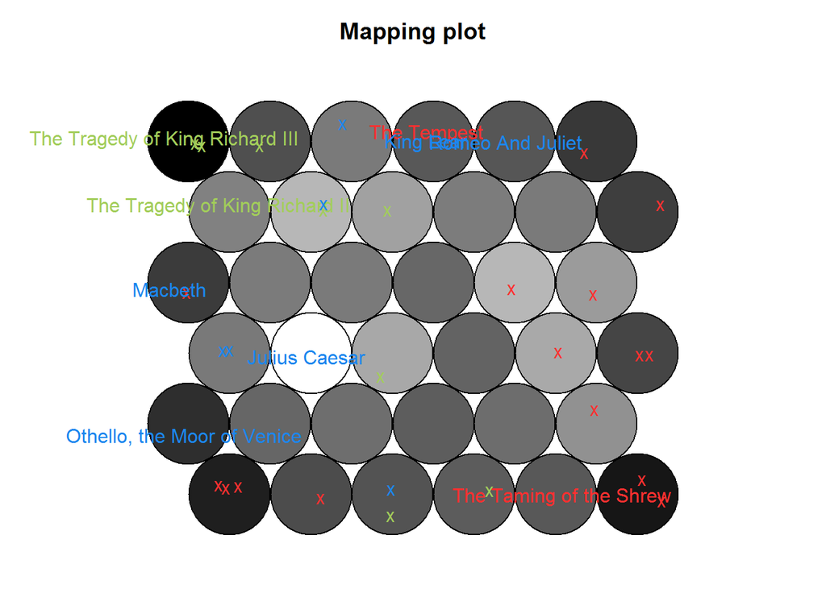

```r
plot(play.SOM,
     type = "mapping",
     col = palette.3[as.factor(play_table$genre)],
     bgcol = hsv(h=0,s=0,v=code.distances(play.SOM)),
     labels = play.labels)
```

We’ve used the distance function to set the *value* for the background gray tone. Larger distance to neighbors corresponds with a value close to 1, and a lighter color. Alternatively, cells with dark backgrounds are closer to their neighbors.

In the next part of this tutorial we’ll use characters instead of plays to create a SOM, which gives us many more documents to visualize in our corpus. [Self Organizing Maps and Text Mining - Shakespeare SOMs (Part 2)](https://clarkdatalabs.github.io/soms/SOM_Shakespeare_Part_2)